# S6_informe

#### Asimismo dada la complejidad tras recabar informacion de nuestra base de datos decidimos eliminara tres variables cualitativas, estas son “causas”, “motivos” y “gastos comunes”

```r
data0<- select(data0, -"Causas",-"Gastos",-"Motivo")
names(data0)
```

```
##  [1] "Edad"          "Sexo"          "Peso"          "Estatura"
##  [5] "Carrera"       "Procedencia"   "Residencia"    "Beca"
##  [9] "Independiente" "Ciclo"         "Org_est"       "Voluntariado"
## [13] "Promedio"      "Autoeval"      "Horas_est"     "Horas_sue"
## [17] "Alim_menor"    "Alim_nut"      "Extra"         "Amigos"
## [21] "Expres_pub"    "Horas_fam"     "Prob_acad"     "Prob_emo"
## [25] "Prob_eco"      "Ingreso"       "din_gasto"     "din_ahorro"
```

Finalmente podemos afirmar que nuestra data esta limpia y cuenta con datos coherentes en todas variables

### Analisis del IMC

Analizaremos las siguientes variables Estatura y Peso dividiendo la dataframe en dos segun la variable independiente.

Hipostesis: Considerames que la mayoria de Estudiates universitarios de UTEC que son independientes tienen indices de masa corporal con valores que indicarian que tenien delgades en su mayoria.

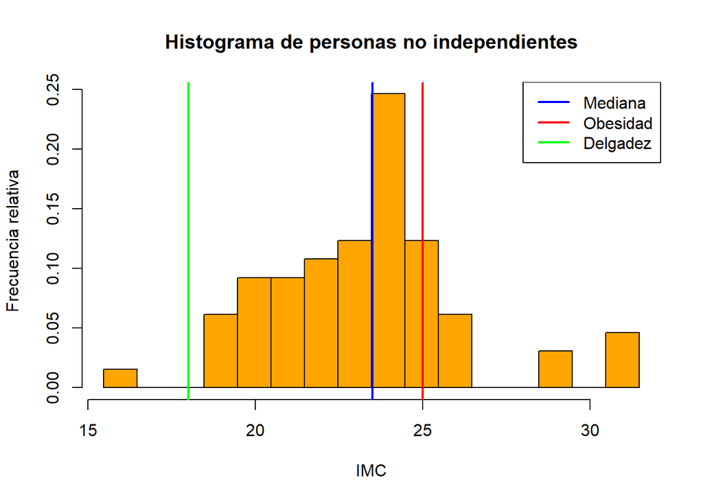

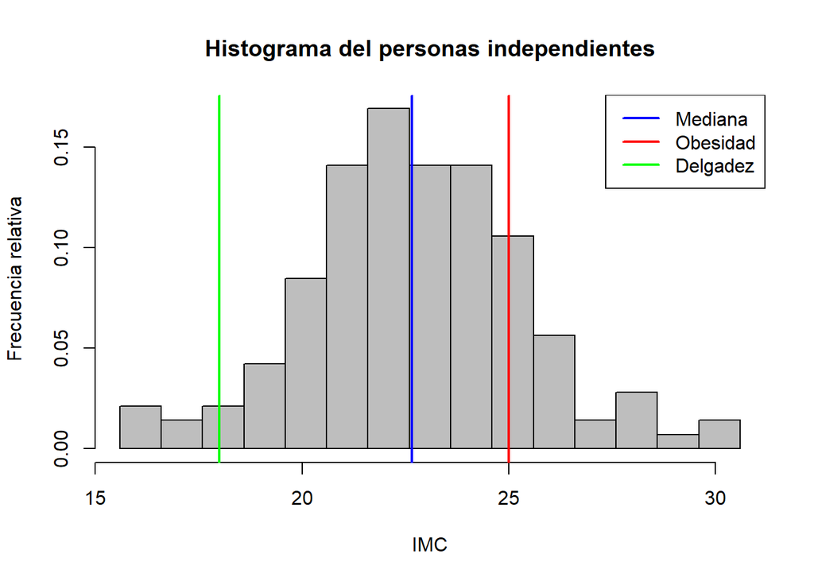

```r
shapiro.test(IMC)
```

```
##
##  Shapiro-Wilk normality test
##
## data:  IMC
## W = 0.94431, p-value = 0.005578
```

```r
shapiro.test(IMC2)
```

```
##
##  Shapiro-Wilk normality test
##
## data:  IMC2
## W = 0.98965, p-value = 0.3768
```

Conclusiones: Segun los datos recopilados y los 2 histogramas mostrados podemos ver que no hay una diferencia notable entre los IMC de los estudiantes independientes como no independientes. sin embargo la distribucion es normal en el caso del IMC de los independientes, ya que si p-value<0.05 hay evidencia suficiente para decir que la muestra no proviene de una población con distribución normal.

### Análisis de Alimento menos comun

Analizaremos la variable de alimento menos consumido durante el dia con respecto a la independencia, la hipotesis es que los estudiantes de la INDEPENDIENTES son mas propensos a ignorar el desayuno a diferencia de los NO independientes

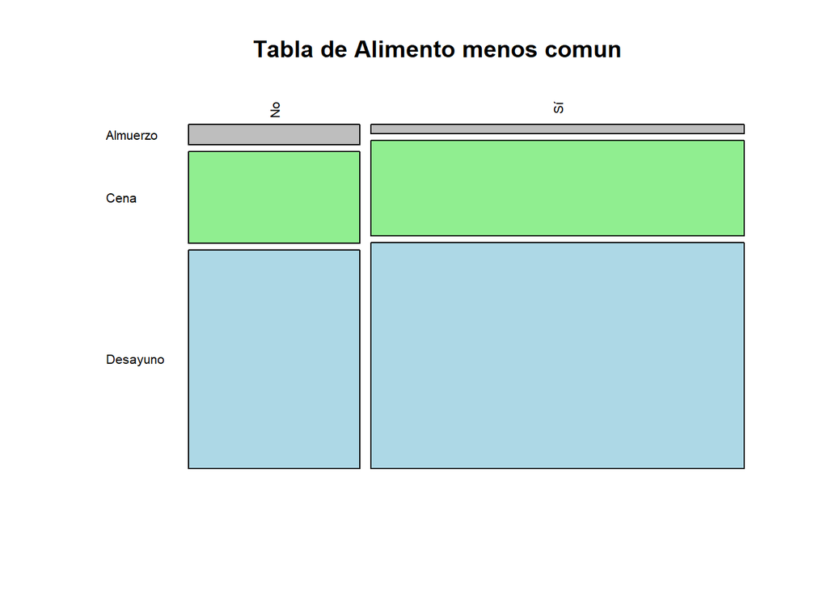

Conclusiones: No hay una diferencia significativa entre los estudiantes independientes y no independientes, puesto que en ambos casos hay tendencia a generalmente dejar de lado el desayuno, recomendamos hacer mayor investigacion sobre el tema ya que consigo pueden acarrear problemas de habitos alimenticios y problemas de salud como la gastritis

### Analisis de BECA

Analizamos la variable categorica nominal Beca diferenciando los datos entre independientes y no independientes, partiendo de la hipotesis que en Utec hay mas becados que no becados en relacion a cantidad, asi tambien la hipotesis de que hay mas cantidad de becados inpendientes que dependientes

```
##
##      Beca 18 Beca Avanzando Juntos Beca BCP Beca Hijo de Docente Beca Inclusión
##   No      26                     0        0                    0              2
##   Sí     110                     2        2                    9              0
##
##      Beca Mujeres en la Ciencia Beca UTEC No cuento con ningún tipo de Beca
##   No                          0         2                                35
##   Sí                          5         0                                14
```

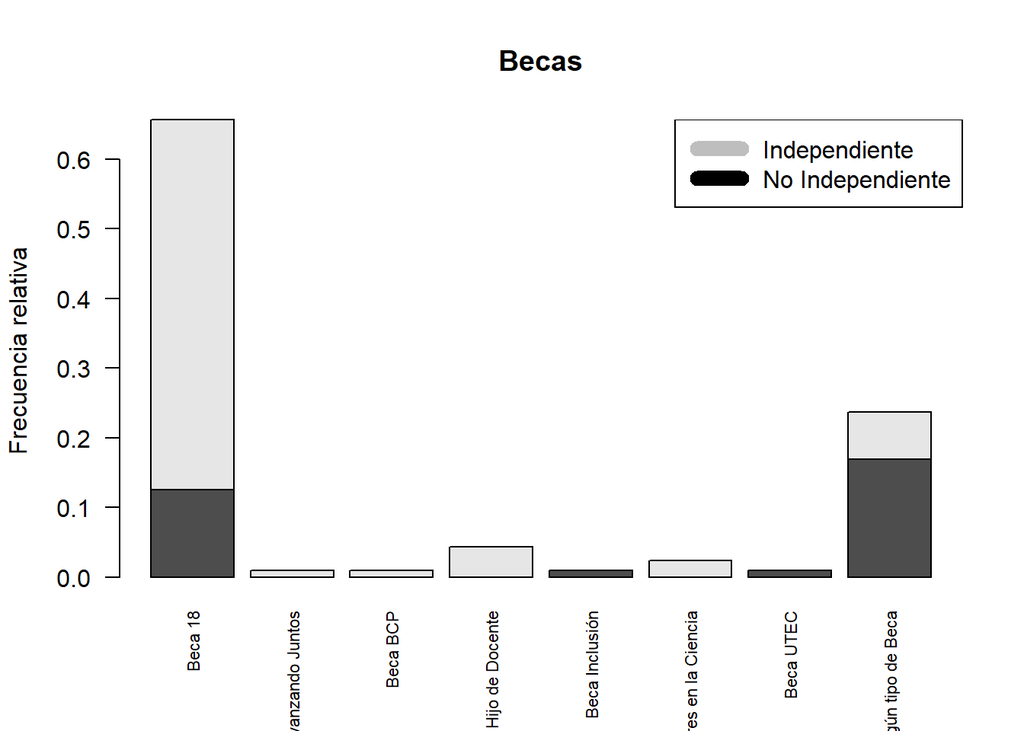

Conclusiones: Efectivamente las dos hipotesis son ciertas

### Independencia y sexo

partiendo de la hipotesis, en UTEC hay mas hombres independientes que mujeres independientes y ademas hay mas mujeres dependientes que hombres dependientes

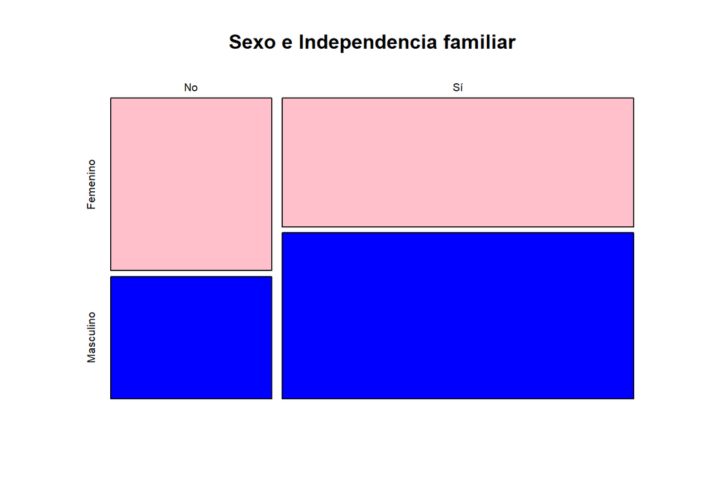

### Carreras de los encuestados en relacion a la independencia familiar

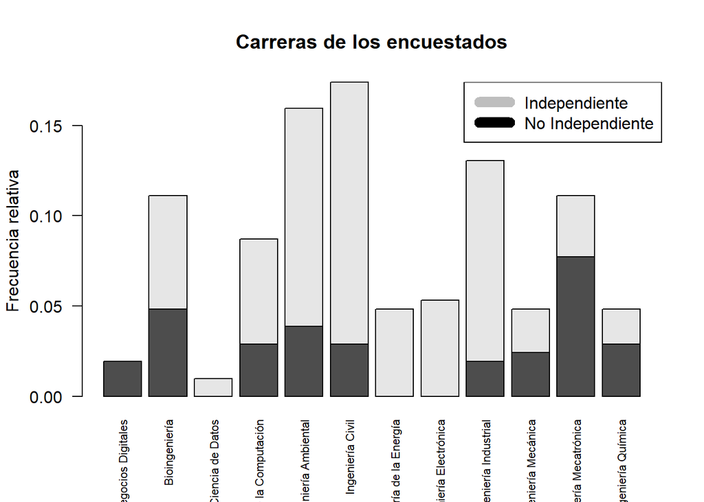

### Independencia familiar y procedencia

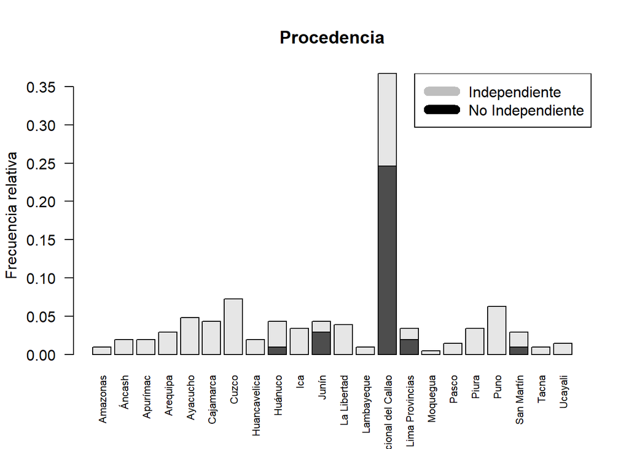

En porporcion lo logico se hace evidente, puesto que es logico que los estudiantes de provincia vivan de manera independiente, esto por ejemplo podriamos corroborarlo con motivos de independencia. No obsteante esta variable fue dificil de manejar y fue eliminada

### Residencia e Independencia

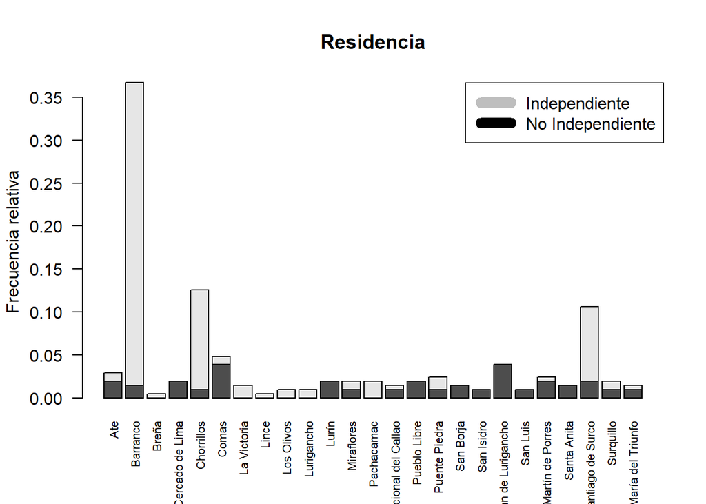

Podemos deducir a partir de los graficos que mientras mas cerca esten de la UTEC hay mayor proporcion de estudiantes que son Independientes

### Horas de estudio e independencia

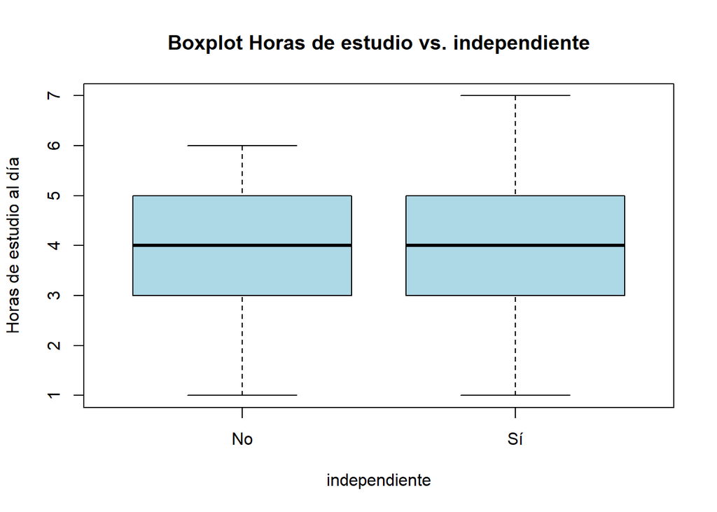

```r
boxplot(data0$Horas_est~data0$Independiente, col="lightblue", main="Boxplot Horas de estudio vs. independiente", ylab="Horas de estudio al día", xlab="independiente")
```

Los estudiantes en general invierten casi la misma cantidad de tiempo para estudiar.

### Extras

Debido a la cantidad de variables y el limitado numero de palabras a utilizar se ha obtado por presentar graficas de interpretacion grafica, los cuales consideramos que son importantes para analizar.

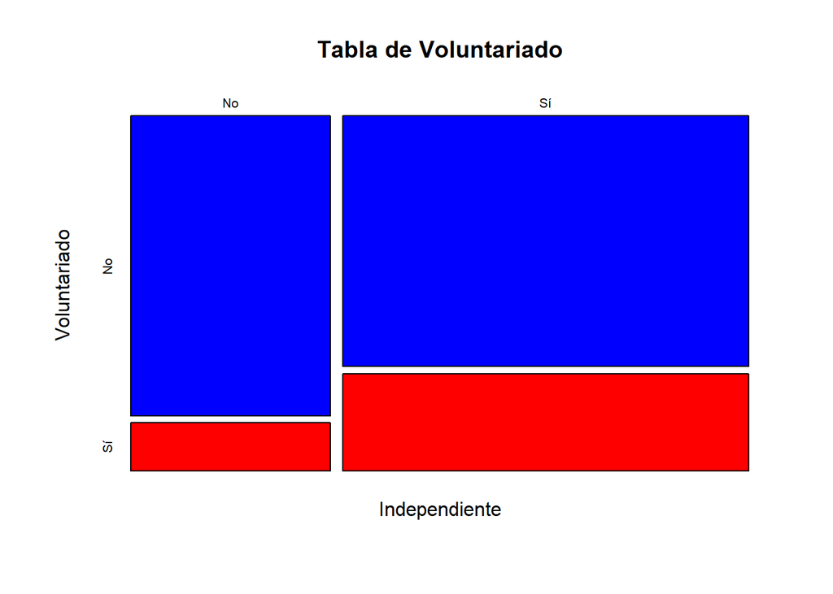

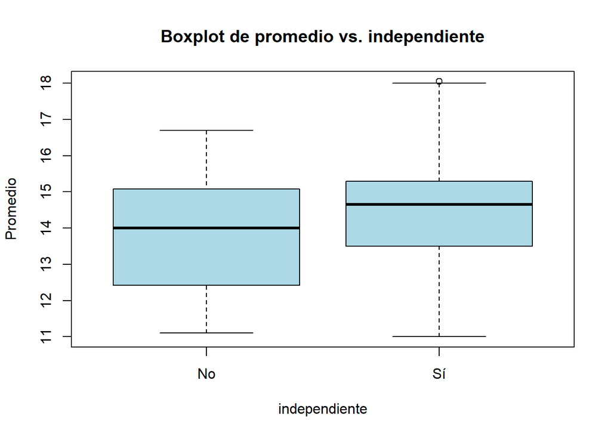

```r
boxplot(data0$Promedio~data0$Independiente, col="lightblue", main="Boxplot de promedio vs. independiente", ylab="Promedio", xlab="independiente")
```

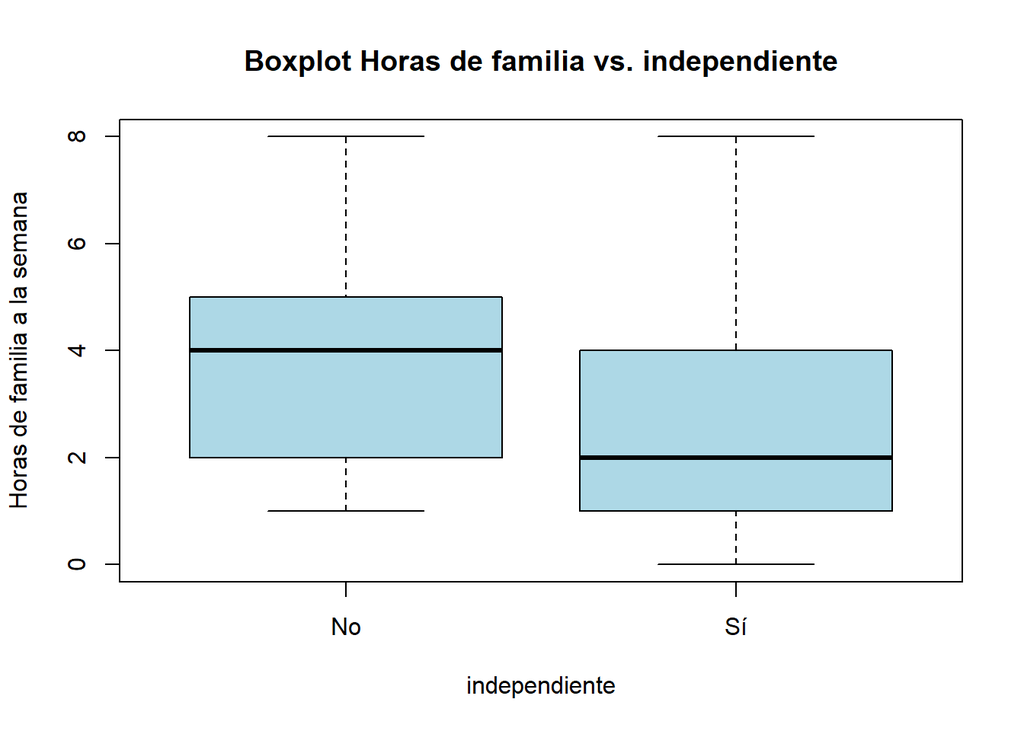

```r
boxplot(data0$Horas_fam~data0$Independiente, col="lightblue", main="Boxplot Horas de familia vs. independiente", ylab="Horas de familia a la semana", xlab="independiente")
```

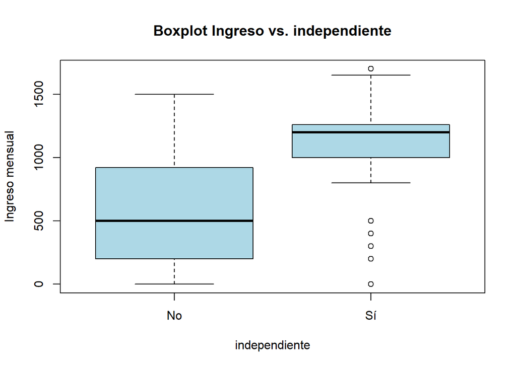

```r
boxplot(data0$Ingreso~data0$Independiente, col="lightblue", main="Boxplot Ingreso vs. independiente", ylab="Ingreso mensual", xlab="independiente")
```

Es logico debido a que la mayoria de nuestra muestra es de beca 18, por ende el ingreso es acertado

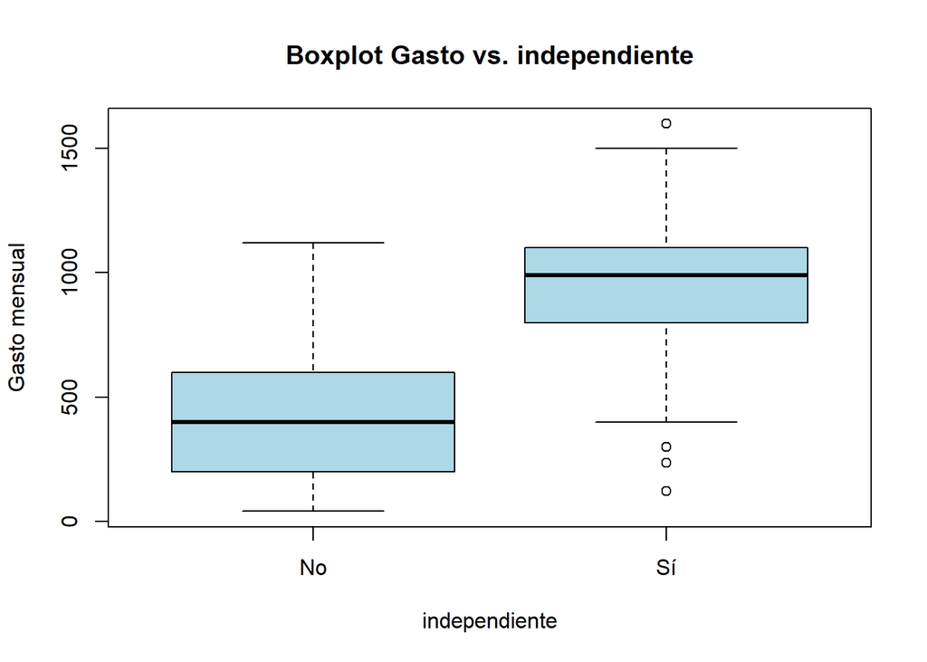

```r
boxplot(data0$din_gasto~data0$Independiente, col="lightblue", main="Boxplot Gasto vs. independiente", ylab="Gasto mensual", xlab="independiente")
```

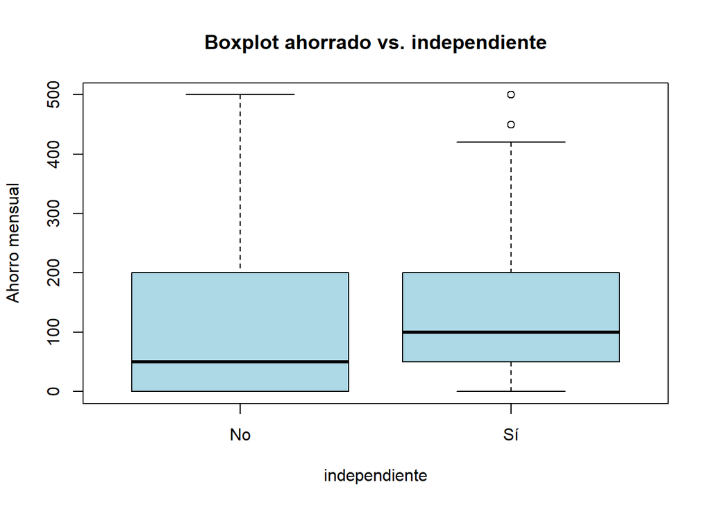

```r
boxplot(data0$din_ahorro~data0$Independiente, col="lightblue", main="Boxplot ahorrado vs. independiente", ylab="Ahorro mensual", xlab="independiente")
```

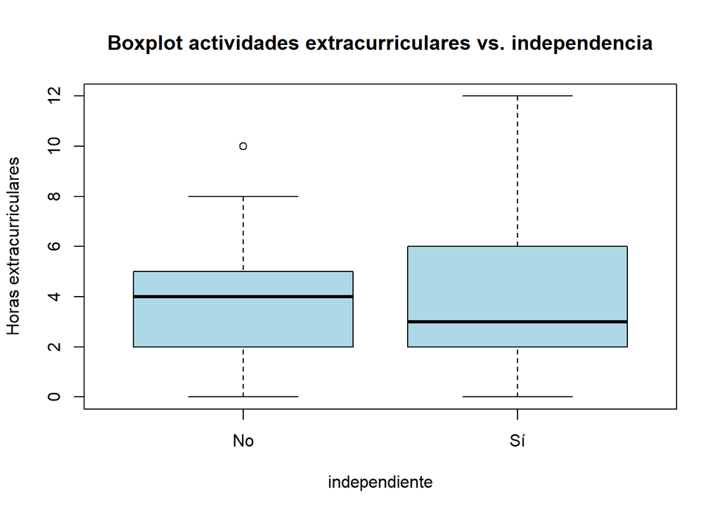

```r
boxplot(data0$Extra~data0$Independiente, col="lightblue", main="Boxplot actividades extracurriculares vs. independencia", ylab="Horas extracurriculares", xlab="independiente")
```

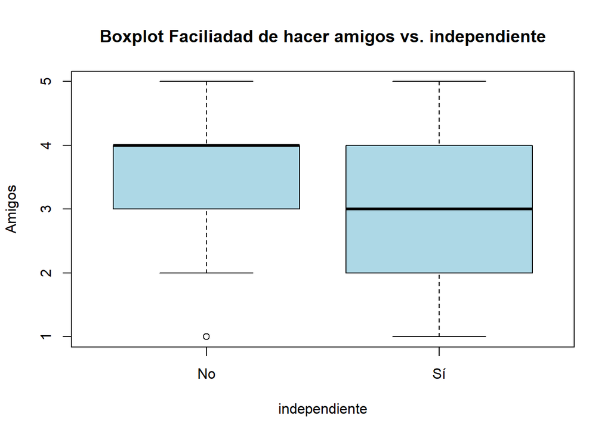

```r
boxplot(data0$Amigos~data0$Independiente, col="lightblue", main="Boxplot Faciliadad de hacer amigos vs. independiente", ylab="Amigos", xlab="independiente")
```

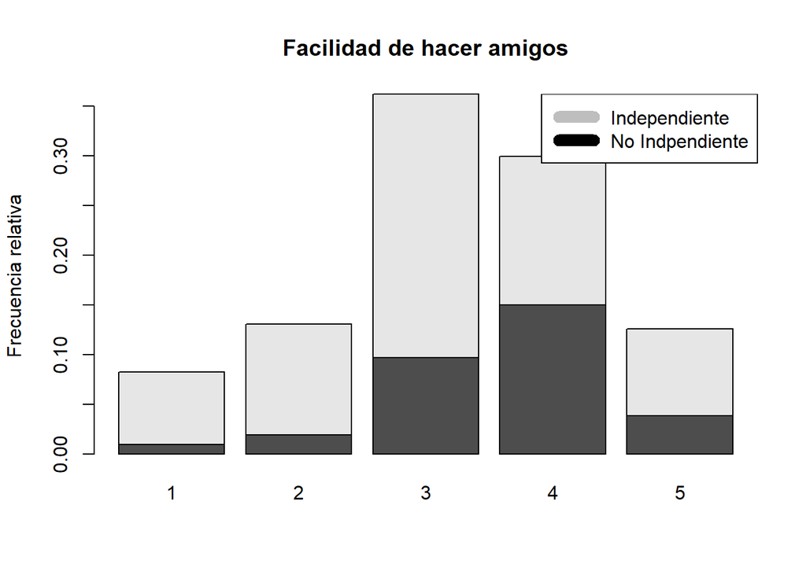

```r
TAM<-table(data0$Independiente,data0$Amigos)
barplot(TAM/nrow(data0),ylab = "Frecuencia relativa",main = "Facilidad de hacer amigos")
legend("topright", legend=c("Independiente","No Indpendiente"), col=c( "Gray","Black"), lwd =10)
```

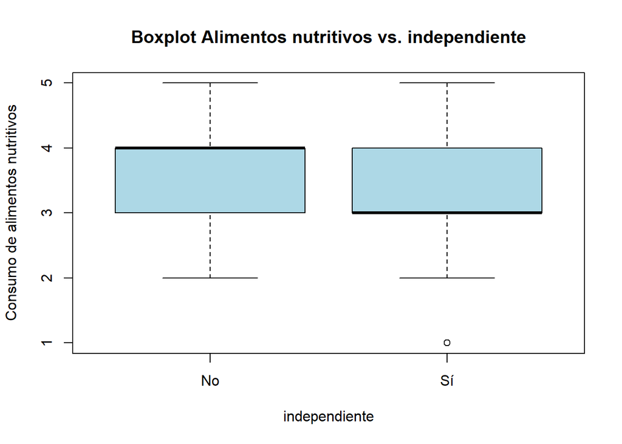

```r
boxplot(data0$Alim_nut~data0$Independiente, col="lightblue", main="Boxplot Alimentos nutritivos vs. independiente", ylab="Consumo de alimentos nutritivos", xlab="independiente")
```

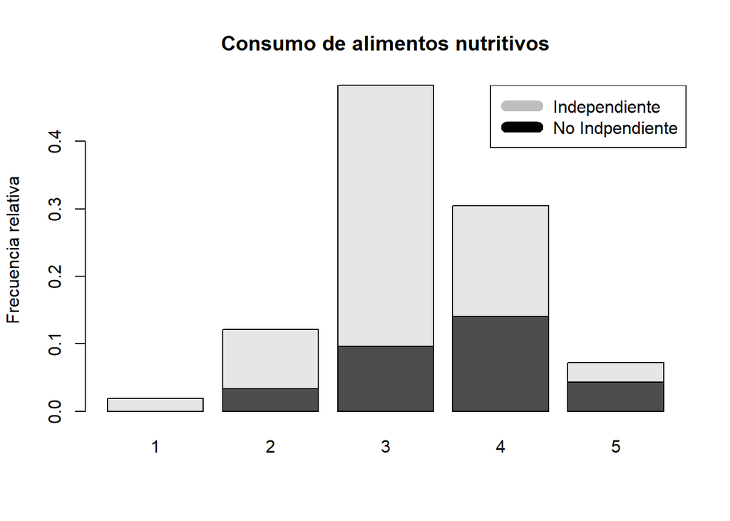

```r
TAL<-table(data0$Independiente,data0$Alim_nut)
barplot(TAL/nrow(data0),ylab = "Frecuencia relativa",main = "Consumo de alimentos nutritivos")
legend("topright", legend=c("Independiente","No Indpendiente"), col=c( "Gray","Black"), lwd =10)
```

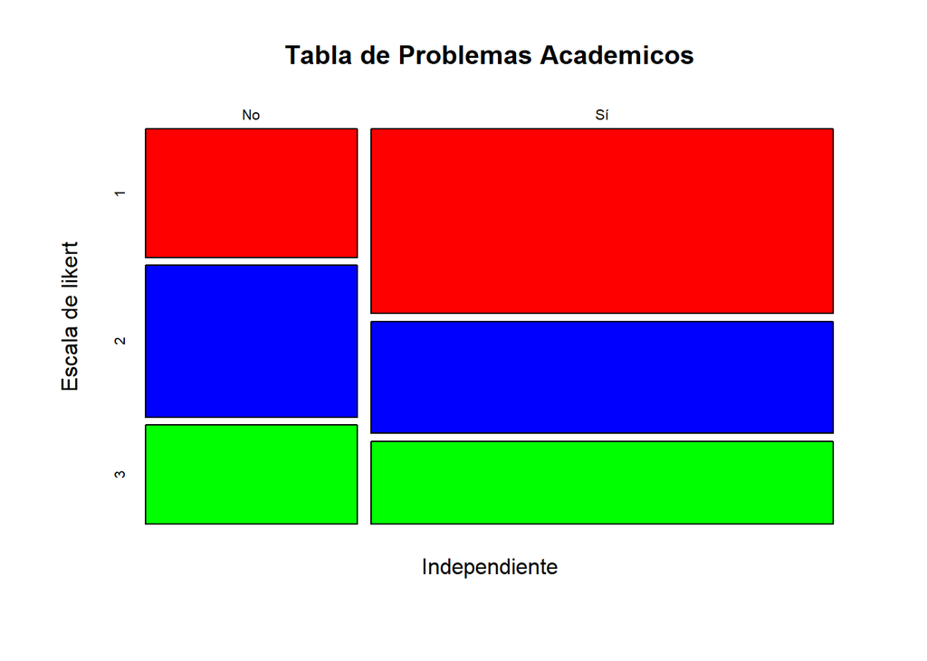

```r
TPA<-table(data0$Independiente,data0$Prob_acad)
Colores<-{}
Colores["1"]<-"RED"
Colores["2"]<-"Blue"
Colores["3"]<-"Green"
mosaicplot(TPA,col=Colores[dimnames(TPA)[[2]]],main="Tabla de Problemas Academicos",xlab = "Independiente",ylab = "Escala de likert")
```

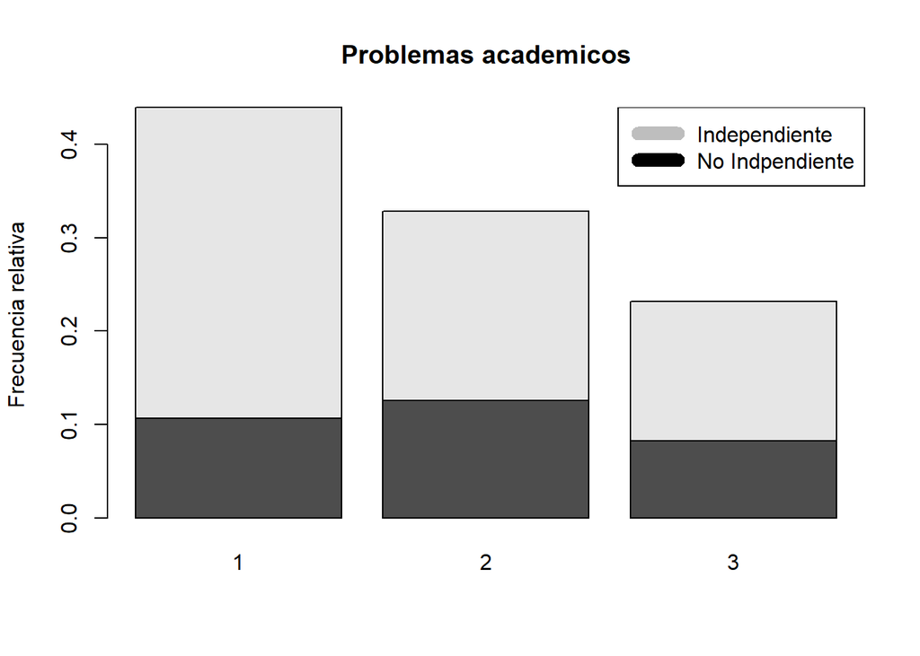

```r
barplot(TPA/nrow(data0),ylab = "Frecuencia relativa",main = "Problemas academicos")
legend("topright", legend=c("Independiente","No Indpendiente"), col=c( "Gray","Black"), lwd =10)
```

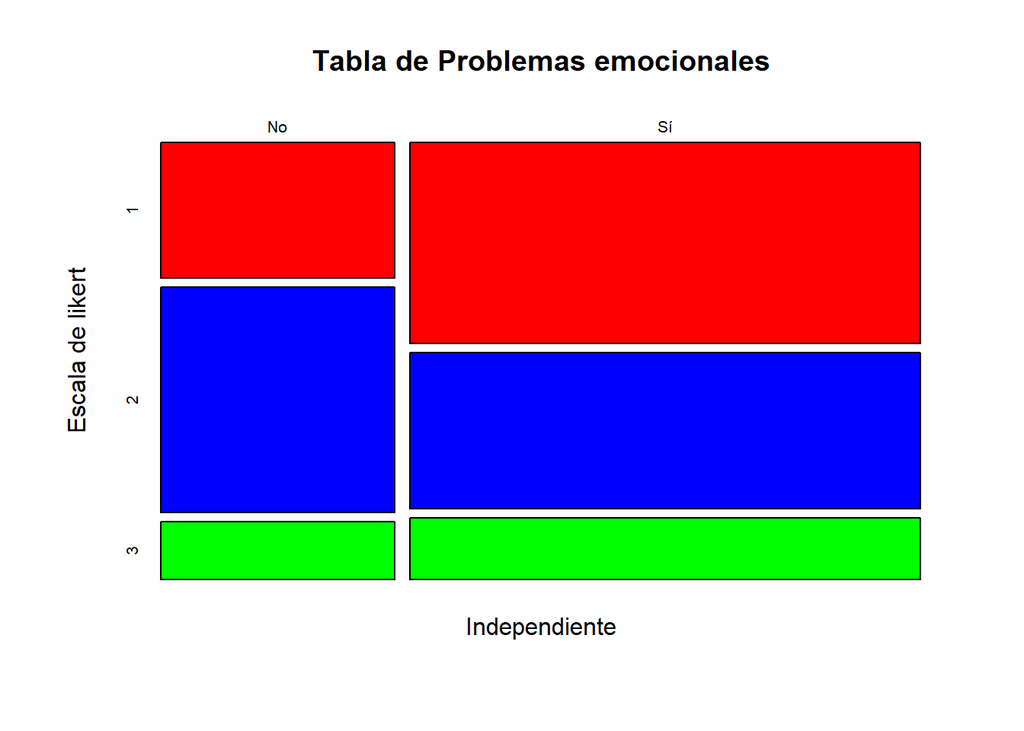

```r
TPE<-table(data0$Independiente,data0$Prob_emo)
Colores<-{}
Colores["1"]<-"RED"
Colores["2"]<-"Blue"
Colores["3"]<-"Green"
mosaicplot(TPE,col=Colores[dimnames(TPE)[[2]]],main="Tabla de Problemas emocionales",xlab = "Independiente",ylab = "Escala de likert")
```

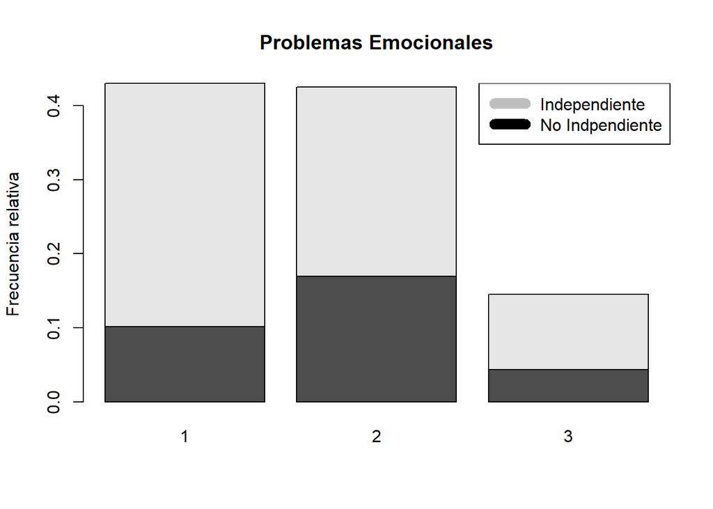

```r
barplot(TPE/nrow(data0),ylab = "Frecuencia relativa",main = "Problemas Emocionales")
legend("topright", legend=c("Independiente","No Indpendiente"), col=c( "Gray","Black"), lwd =10)
```

## Diagramas de dispersión

```r
cor(data0$Ingreso,data0$din_gasto)
```

```
## [1] 0.6509196
```

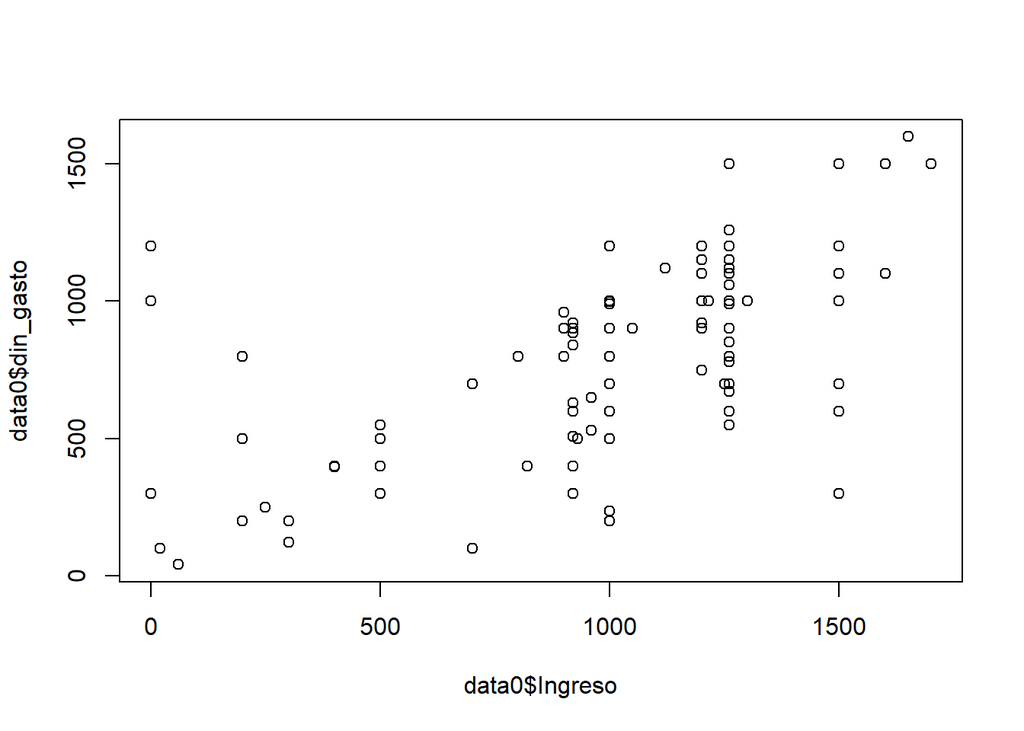

```r
plot(data0$Ingreso,data0$din_gasto)
```

```r
cor(data0$Ingreso,data0$din_ahorro)
```

```
## [1] 0.286853
```

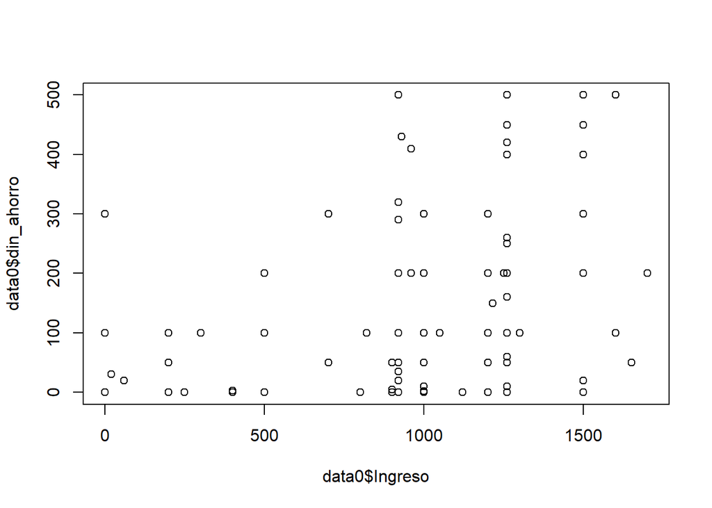

```r
plot(data0$Ingreso,data0$din_ahorro)
```

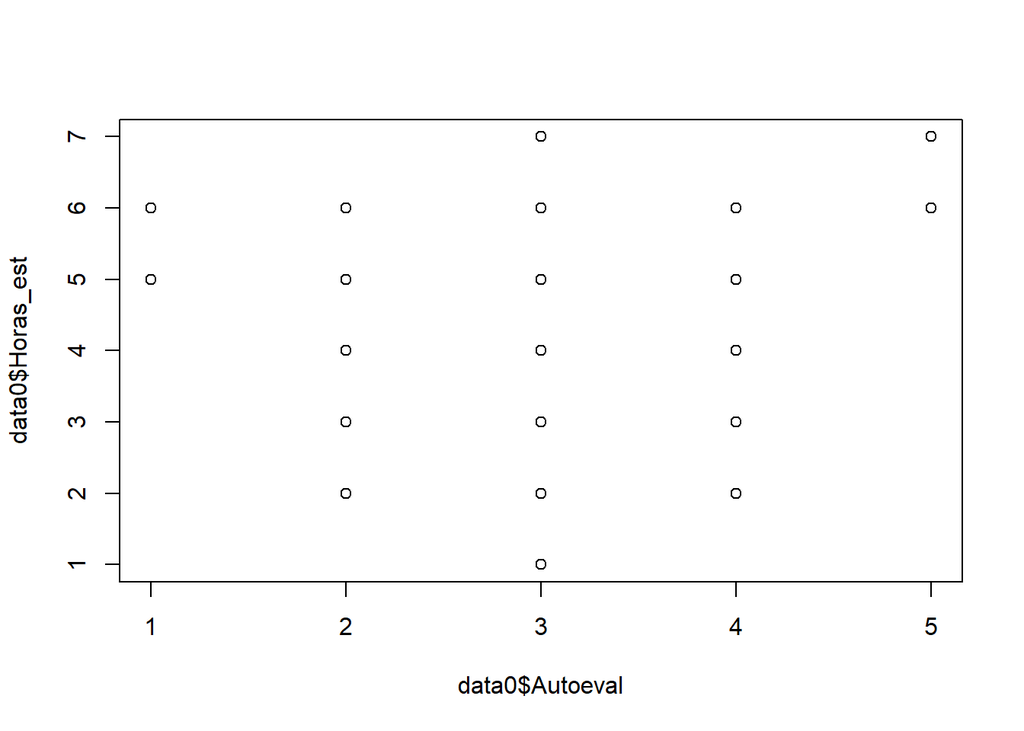

```r
plot(data0$Autoeval,data0$Horas_est)
```

```r
cor(data0$Autoeval,data0$Horas_est)
```

```
## [1] -0.005230399
```

El valor de la correlacion entre las horas de estudio y la autoevaluacion, tiende a 0, el grafico muestra una incorrelacion, por lo que no estan relacionadas

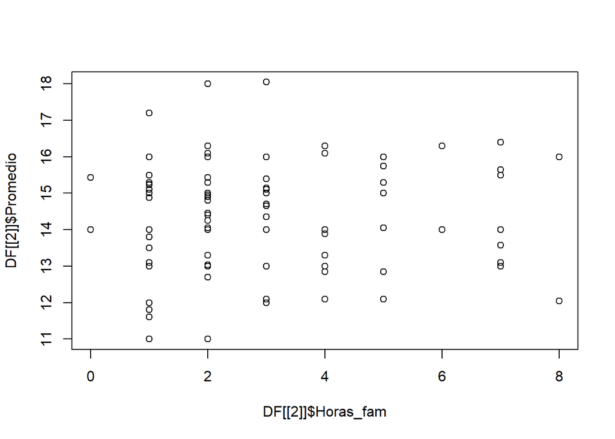

```r
plot(DF[[2]]$Horas_fam,DF[[2]]$Promedio)
```

```r
cor(DF[[2]]$Horas_fam,DF[[2]]$Promedio,use="na.or.complete")
```

```
## [1] 0.07675585
```

El valor de la correlacion entre el promedio y las horas de comunicacion familiar, tiende a 0, el grafico muestra una incorrelacion, por lo que no estan relacionadas

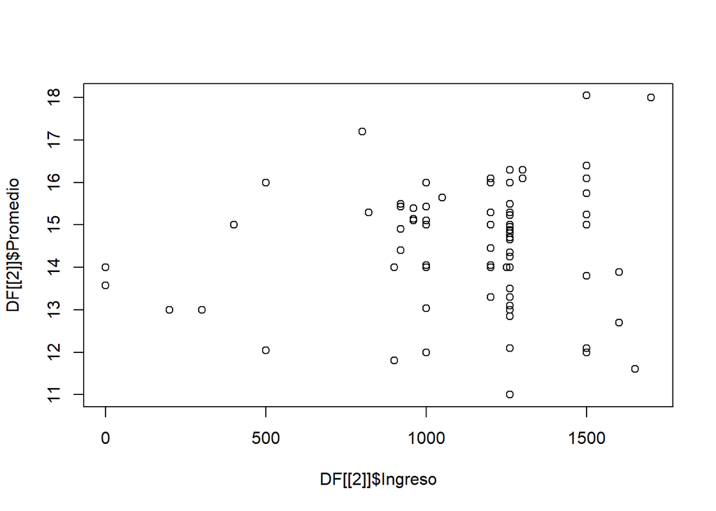

```r
plot(DF[[2]]$Ingreso,DF[[2]]$Promedio)
```

```r
cor(DF[[2]]$Ingreso,DF[[2]]$Promedio,use="na.or.complete")
```

```
## [1] -0.000594467
```

El valor de la correlacion entre el promedio y el ingreso, tiende a 0, el grafico muestra una incorrelacion, por lo que no estan relacionadas